# Data Organization with Excel 2

Pete E. Pascuzzi

# Setup

For Purdue University students, **you cannot save fies to the lab computer!** However, your ITaP home directory should be mapped as the `W:` drive. Remember to drag your work to your home directory before you log out!

[figure not shown]

**Important! Make Windows 10 show file name extensions by doing the following**

1. Left-click on an empty area of the Desktop.
2. Enter `Ctrl + n` to open a File Explorer Window.
3. Select the `View` tab at the top of the window.
4. Check the box next to `File name extensions`.

[figure not shown]

This will make it much easier for you to identify the correct files for the workshop. **File extensions are an important part of a file name!**

Locate the Excel02 folder for the workshop on the `lab (R:`) drive on the lab computers, `This PC > lab (R:) > PascuzziPE > Excel02` .

[figure not shown]

[figure not shown]

[figure not shown]

Drag the Excel02 folder to your desktop.

# Introduction

This workshop builds on the workshop, Data Organization with Excel 1. So, it is assumed that you know use the following:

- Text Import Wizard
- Data Filtering
- Data Validation
- Basic Pivot Tables

Today, we are going to add four new skills to your Excel arsenal:

- Data Queries
- Pivot Charts
- VLOOKUP
- Data Subsetting with Data Filters

# Data Queries

When you work in Excel, your data is typically an integral part of your Excel project, i.e. the data is saved in the Excel spreadsheet. Some data sets can be too large to work with Excel easily. In addition, for large data sets, you may only need to analyze a subset of the data.

**Data queries** allow you to link to data external to Excel and to extract only the data that you need. You then manipulate and analyze a data set minimizing the risk of compromising the original data. **Remember, datasets are easily corrupted by Excel through accidental data entry!** A **data query** minimizes that risk.

In this exercise, we are going to use a data set for airlines flights originating in New York City airports in 2013. This data set has over 300,000 rows making it a bit challenging for Excel. For this workship, our goal is to identify carriers with excessive delays from JFK in the month of December, so we do not need to use all of the data in the first place.

## Protocol

1. Open Excel and select a Blank workbook.

[figure not shown]

2. Select the `Data` tab then click on `New Query`.

[figure not shown]

3. Select `From File` > `From Text` .

[figure not shown]

4. Browse to the `flights.txt` file in the workshop folder and import this file.

[figure not shown]

5. A preview window for the data file will open. Click `Edit`, **not Load**!

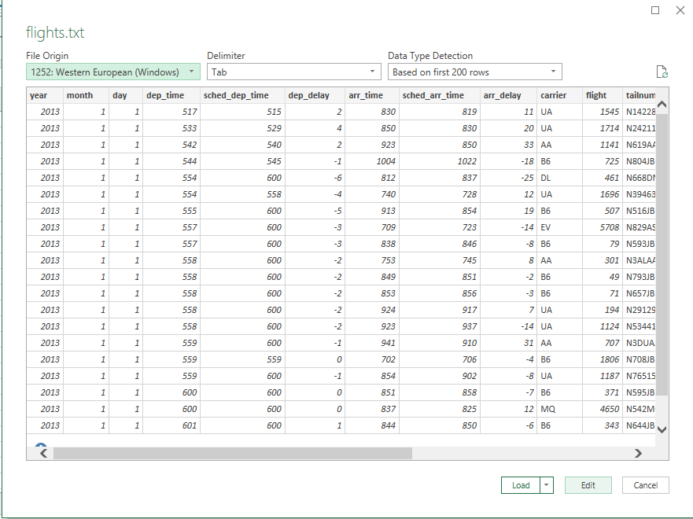

5. The Power Query Editor window will open. From here, you can select specific rows or columns of the data set, change data types, and a host of other operations.

[figure not shown]

7. This data set contains flight information for major airports around New York City for 2013, and includes more than 300,000 records. At the top of each column, is the column name. Excel also indicates its estimate for data type with icons before the column name. There are numbers for numeric data, letters for text data, etc.
8. Click on the drop down arrow at the top of the `month` column. You should see only 1 as possible values here and a warning that the list may be incomplete.

[figure not shown]

9. Click `load more`. You should see the list populate to include months 2 - 12. Uncheck Select All and check only 12. Hit `OK`.

[figure not shown]

9. Go to the `origin` column and click on the drop down arrow. Click on Load More to confirm that all possible values for this variable appear. Uncheck Select All, check JFK, and click OK.

[figure not shown]

10. Scan across each column (or variable). Confirm that the data type makes sense. All times and distances should be whole numbers. The `time_hour` column is a date.
11. Load the selected data by clicking Close & Load at the top left. The selected data should now load into a new worksheet.

[figure not shown]

[figure not shown]

[figure not shown]

We are now ready to analyze the data query with a Pivot Table and Chart.

# Pivot Tables and Charts

Excel Pivot Tables and Charts allow you to summarize and analyze your data. They are rather cumbersome to use, but, with some practice, they allow you to perform operations that are not possible within the confines of the spreadsheet itself.

## Protocol

1. Select the Insert tab and click on PivotChart.

[figure not shown]

2. Make sure the flights data appears as the table and insert as a new sheet.

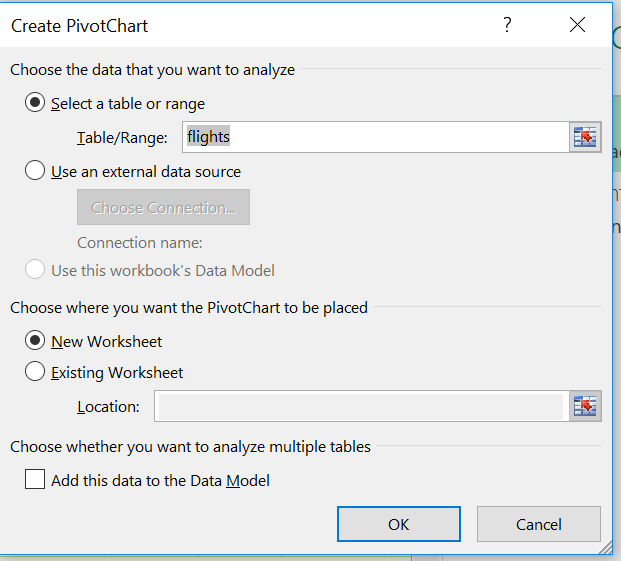

3. We want to examine departure delays as a function of departure time to help schedule future flights. Drag `sched_dep_time` to the AXIS box and `dep_delay` to the VALUES box.

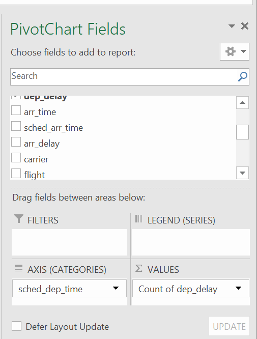

4. Change the Value field settings so that `dep_delay` is shown as Average.

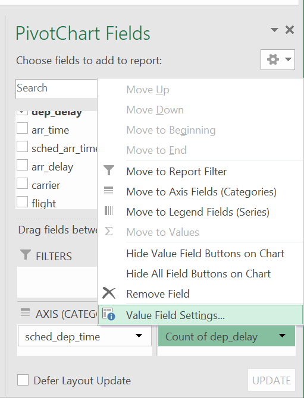

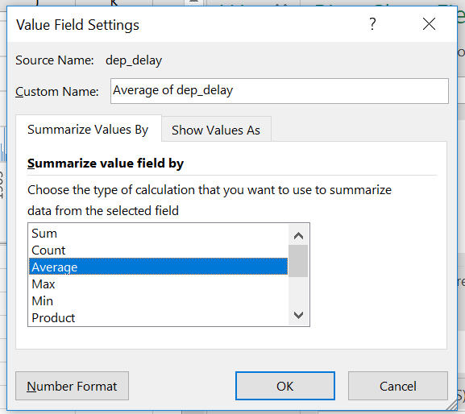

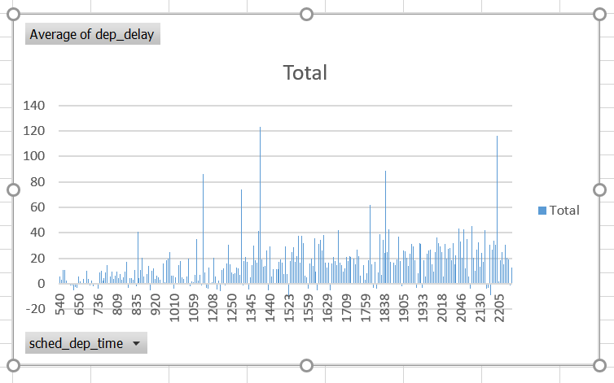

This plot is not very informative, possibly because the `sched_dep_time` is too precise. Perhaps we should bin these into hourly intervals. We can use the Excel function **VLOOKUP** to do this data transformation.

# VLOOKUP

The **VLOOKUP** function is used in Excel to provide a bridge between different types of data. For example, the function can be used to lookup the price for a given item. Here, we are going to use it to take the (nearly) continuous variable `sched_dep_time` and transform it to an hourly departure time or range.

1. Go back to the worksheet with the flights data.
2. Make a new column called `sdd_bin`. This should be column `T` in your worksheet.

[figure not shown]

3. In the column next to that, i.e. column `U`, you need to enter the numbers 500 - 2400 incremented by 100. The easy way to do this is with Excel **Fill**. Enter 500 in cell U2.

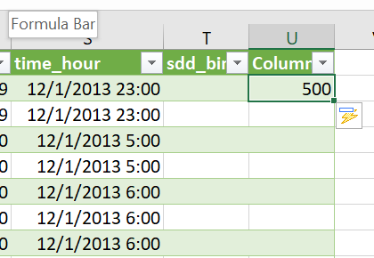

4. From the Taskbar, select Fill > Series.

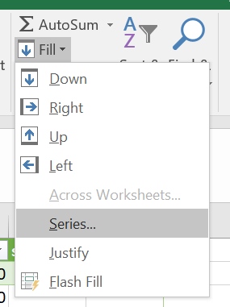

5. Select `Series in` Columns, and enter a `Step value` of 100 and a `Stop value` of 2400. Hit OK.

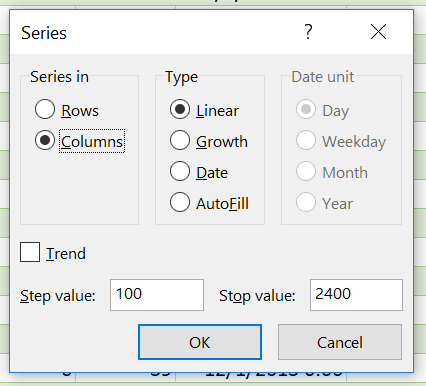

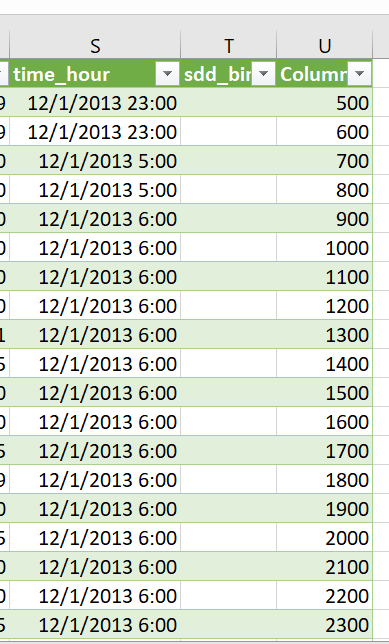

4. In column `V`, copy and paste the numbers from column `U`. The data in columns `U` and `V` are the table that Excel needs with **VLOOKUP**.

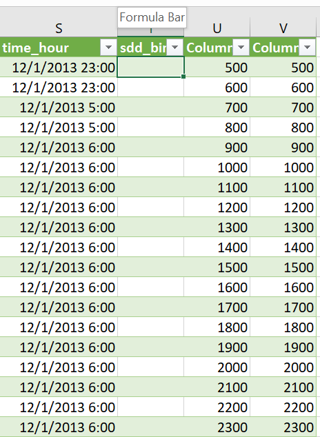

5. In the `sdd_bin` column enter this formula, `=VLOOKUP(E2, $U$2:$V$21, 2, TRUE)`

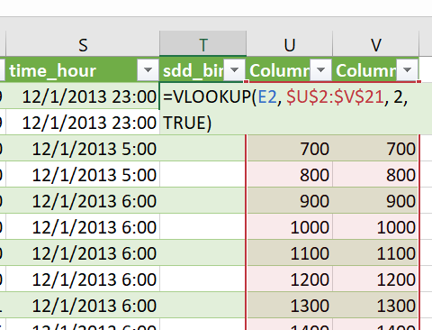

6. Excel will use this formula to match the `sched_dep_time` in column `E` to the range of values in our table and return the result.

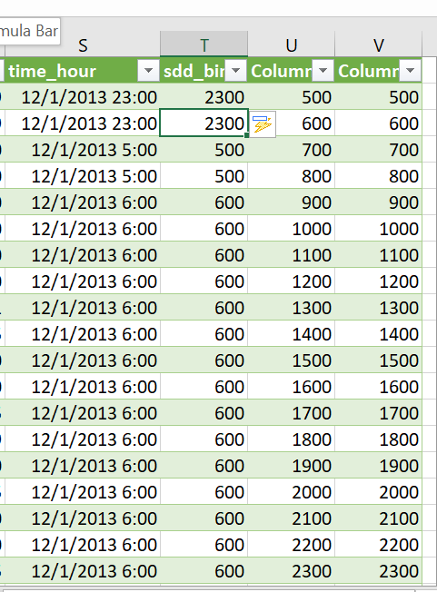

You can use **VLOOKUP** to transform many variables based on tables of your design. For more on **VLOOKUP**, see this [Microsoft Support Page](https://support.office.com/en-us/article/vlookup-function-0bbc8083-26fe-4963-8ab8-93a18ad188a1).